# Replication Exercise

Tristan Misko

11/10/2021

# Section 1: Overview of Paper

## Question 1: In general, we would expect the causal effect of police presence

on car thefts to be negative via a deterence effect. The regression
$$\text{car_theft}_d = \alpha + \beta\text{police+officers}_d + \sum_{k=1}^K\gamma_kX_{k,d} + \epsilon_d$$
likely suffers significantly from omitted variables bias. In particular, it is likely that districts which have experienced high levels of car theft in the past are likely to have higher levels of police presence in response and are also likely to suffer from more car thefts during the response period. This positive correlation would bias the downward the magnitude of estimated causal effect $\hat\beta$, making it less negative than the true causal effect, and could even induce a perverse positive sign.

## Question 2: The paper's research design uses plausibly exogenous shocks to

police presence heterogeneously dispersed across districts to obtain causal estimates for the effect of policing on car thefts. The protection mandate for Jewish and Muslim institutions was implemented at the national level, so the increase in police presence in the vicinities of these institutions is unrelated to potential local police responses, eliminating the main source of confounding.

## Question 3: The parallel trends assumption is crucial to the analysis

performed

# Section 2: Dataset was downloaded and manipulated inside of $R$.

```r
# read in data
mp2 <- read.csv("MonthlyPanel2.csv", header = T)
```

# Section 3:

```r
ctg <- Vectorize(function(distanci){
    if (distanci == 0){
        return(1)
    } else if (distanci == 1){
        return(2)
    } else if (distanci == 2){
        return(3)
    } else {
        return(4)
    }
}, "distanci")
mp2$category <- ctg(mp2$distanci)
unique(mp2$mes)
```

```
##  [1]  4  5  6  7  8  9 10 11 12 72 73
```

## Exercise 2: We use the `filter` function from the `dplyr` package to remove

all observations for which `mes` takes value 72.

```r
mp2 <- filter(mp2, mes != 72)
```

## Exercise 3: We generate the variable `month` which takes the value of `mes`

if `mes` is less than or equal to seven and `mes + 1` otherwise.

```r
mes.shift <- Vectorize(function(mes){
    if (mes <= 7){
        return(mes)
    } else {
        return(mes + 1)
    }
}, "mes")
mp2$month <- mes.shift(mp2$mes)
unique(mp2$month)
```

```
##  [1]  4  5  6  7  9 10 11 12 13 74
```

## Exercise 4: We map values of `month` which are equal to 74 to the value 8.

```r
month.shift <- Vectorize(function(month){
    if (month == 74){
        return(8)
    } else {
        return(month)
    }
}, "month")
mp2$month <- month.shift(mp2$month)

#check that the remapping has worked correctly
sort(unique(mp2$month))
```

```
##  [1]  4  5  6  7  8  9 10 11 12 13
```

## Exercise 5: Since $R$ does not use the same labelling conventions as STATA,

we opt to store the labels as a column in the table containing the desired string values.

```r
label.month <- Vectorize(function(month){
    label.as <- c("April",
                  "May",
                  "June",
                  "July (1-17)",
                  "July (18-31)",
                  "August",
                  "September",
                  "October",
                  "November",
                  "December")
    return(label.as[month - 3])
}, "month")
mp2$month.label <- label.month(mp2$month)
```

## Exercise 6: We store the cleaned data in a new file called `DataClean.csv`.

```r
write.csv(mp2, "DataClean.csv")
```

# Section 4: Descriptives

## Exercise 1:

```r
grouped <- mp2 %>% group_by(month, category) %>% summarize(mean(totrob2))
```

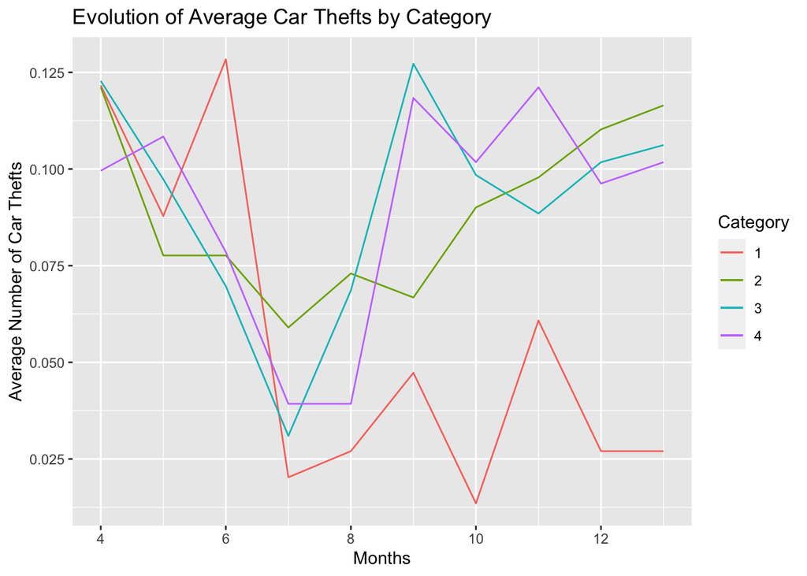

```r
ggplot(, aes(x = month, y = `mean(totrob2)`)) +
    geom_line(data = filter(grouped, category == 1), aes(color = factor(category))) +
    geom_line(data = filter(grouped, category == 2), aes(color = factor(category))) +
    geom_line(data = filter(grouped, category == 3), aes(color = factor(category))) +
    geom_line(data = filter(grouped, category == 4), aes(color = factor(category))) +
    labs(title = "Evolution of Average Car Thefts by Category",
         color = "Category") +
    ylab("Average Number of Car Thefts") + xlab("Months")
```

```r
dat <- read.csv("DataClean.csv")
mean.and.sd <- dat %>% group_by(month.label, category) %>%
    summarize(m = mean(month), mean = round(mean(totrob2),5), sd = round(sd(totrob2), 5))
cat4 <- select(filter(mean.and.sd, category == 4),c(1,3,4,5))
cat1 <- select(filter(mean.and.sd, category == 1),c(1,4,5))
cat2 <- select(filter(mean.and.sd, category == 2),c(1,4,5))
cat3 <- select(filter(mean.and.sd, category == 3),c(1,4,5))
table2 <- select(arrange(select(data.frame(cat4, cat1, cat2, cat3), c(-5, -8, -11)), m), -2)

generate_table_body <- function(table2){
    table_string = ""
    for (row in 1:length(table2$month.label)){
        means <- paste(c(paste(as.character(table2[row,c(1,2,4,6,8)]),
                         collapse = " & "), "\\\\", "\n"), collapse = " ")
        sds <- paste(c(paste(c(" ", paste0("(", as.character(table2[row,c(3,5,7,9)]), ")")),
                             collapse = " & "), "\\\\", "\n"), collapse = "")
        table_string <- paste0(table_string, paste0(means, sds))
    }
    cat(table_string)
}
```